# Cancer-associated venous thrombosis (CAT) cumulative incidence estimation for ONCOTHROMB12-01 cohort

Bárbara Lobato Delgado

```r
# Deactivate scientific notation
options(scipen = 999, na.action = "na.pass", max.print = 10000)
```

```r
# Load libraries
pacman::p_load(
  an9elproject,
  tidyverse,
  lubridate,
  survival,
  pec,
  survminer,
  cmprsk,
  install = FALSE, update = FALSE
)
```

# Introduction

In this analysis we estimate the cancer-associated venous thrombosis (CAT) cumulative incidence in competing risks with death, and plot the cumulative incidence over time for the ONCOTHROMB12-01 cohort.

# Cumulative incidence estimation with competing risks — death *vs* CAT

Death and CAT are events in competing risks, given that death impedes CAT — but not the other way around.

Cumulative incidence describes the probability of a specific event occurring within a certain time frame. It is often used in the context of competing risks, where there are multiple possible events that can occur, and the focus is on estimating the probability of each event type.

In the context of survival analysis with competing risks, the cumulative incidence function (CIF) is used to represent the cumulative probability of experiencing a particular type of event before a given time point, while accounting for the presence of other competing events that could prevent the occurrence of the event of interest.

Mathematically, the cumulative incidence function for a specific event type is defined as:

CIF(t) = P(Event of interest occurs before or at time t)

The cumulative incidence at a specific time point represents the proportion of individuals who have experienced the event of interest up to that time. It’s important to note that as time progresses, the cumulative incidence can increase, but it cannot decrease.

When there are competing risks, each event type will have its own cumulative incidence function. *The sum of the cumulative incidence functions for all event types at any given time point cannot exceed 1, as it represents the entire probability space.*

Cumulative incidence functions are commonly used to compare event rates between different groups or categories, and statistical tests like Gray’s test can be used to assess whether there are significant differences in the cumulative incidence functions across groups. Gray’s test helps you determine if there are statistically significant differences between these CIFs across different groups. It’s an extension of the classical log-rank test used in traditional survival analysis, adapted to the competing risks setting.

```r
# Load DB from an9elproject
oncoth1 = get_project("oncothr1", version = "0.0.8003")
```

```r
# Create dataset with information for estimation con cumulative incidence
cat_cuminc_data = oncoth1$data %>%
  select(id,
         patient_group,
         n_appointment_patient_became_case,
         date_cancer_dx,
         date_dropout,
         date_death,
         date_study_begins,
         date_study_ends,
         patient_status_at_end_study_simplified,
         follow_up_length_from_cancer_diagnosis_days,
         tu_1st_vte_all_from_cancer_diagnosis_days_corrected) %>%
  # Patients that already suffered CAT at time 0 or prior must be excluded
  filter(!n_appointment_patient_became_case == "Beginning of study")
```

A total of 30 patients are excluded in order to estimate CAT cumulative incidence, given that they already suffered CAT at time = 0.

```r
# Now create variables of status (CAT, death w/o CAT or censored) and time until event (CAT or death w/o CAT)
cat_cuminc_data %<>%
  # Status (0 for censored, 1 for CAT, 2 for dead with no CAT)
  mutate(event_status = case_when(
    patient_group == "Control" &
      patient_status_at_end_study_simplified == "Dead" ~ 2,
    patient_group == "Case" ~ 1,
    TRUE ~ 0)) %>%
  # Time until event
  mutate(tu_event = case_when(
    event_status == 0 ~ follow_up_length_from_cancer_diagnosis_days, # censored patients
    event_status == 2 ~ follow_up_length_from_cancer_diagnosis_days, # patients dead w/o CAT
    event_status == 1 ~ tu_1st_vte_all_from_cancer_diagnosis_days_corrected # patients with CAT
  ))
```

```r
# Estimate CAT and death cumulative incidence functions from competing risks data
cat_cuminc = cuminc(
  ftime = cat_cuminc_data$tu_event,
  fstatus = cat_cuminc_data$event_status,
  cencode = 0 # censored patients are encoded as zero
  )

# $est: cumulative incidence estimates at different time points for each type of event (days)
# i is the group index and j is the event
# $var: variances of the cumulative incidence estimates
cat_cuminc
```

```
## Estimates and Variances:
## $est
##           500      1000      1500      2000
## 1 1 0.1527292 0.1659712 0.1659712 0.1659712
## 1 2 0.2461687 0.2892332 0.2892332 0.2892332
##
## $var
##              500         1000         1500         2000
## 1 1 0.0003678709 0.0004000217 0.0004000217 0.0004000217
## 1 2 0.0005348591 0.0006503764 0.0006503764 0.0006503764
```

These are the cumulative incidence functions (CIFs) for developing CAT (1 1) and dying without CAT (1 2) and their respective variances. In spite of the notation, patients are not grouped.

```r
# Estimate CAT and death cumulative estimates functions (CIFs) for group of patients with CAT and w/o CAT
# Get Tests
cat_cuminc_test = cuminc(
  ftime = cat_cuminc_data$tu_event,
  fstatus = cat_cuminc_data$event_status,
  group = cat_cuminc_data$event_status, # patients with CAT vs patients dead w/o CAT
  cencode = 0)[["Tests"]]

# Show the test statistic value, the p-value and the degrees of freedom resulting from comparison of CIFs between groups
cat_cuminc_test
```

```
##       stat pv df
## 1 401.9743  0  2
## 2 406.6024  0  2
```

```r
# Show results in a more intelligible way
cat_cuminc_customised = cat_cuminc %>%
  # Remove Tests from list
  list_modify("Tests" = NULL) %>%
  # Apply a function to each element of list or atomic vector and show in a dataframe
  # Subset "time" and "est" and add id column
  map_df(`[`, c("time", "est"), .id = "id") %>%
  # Add name to groups
  mutate(id = recode(
    id,
    "1 1" = "CAT",
    "1 2" = "Death w/o CAT")) %>%
  # Select event of interest, in this case, CAT
  filter(id == "CAT")

# All time points in CAT CIF estimation
cat_cuminc_customised
```

| id | time | est |
| --- | --- | --- |
| CAT | 0 | 0.000000000 |
| CAT | 10 | 0.000000000 |
| CAT | 10 | 0.002777778 |
| CAT | 23 | 0.002777778 |
| CAT | 23 | 0.005555556 |
| CAT | 35 | 0.005555556 |
| CAT | 35 | 0.008333333 |
| CAT | 74 | 0.008333333 |
| CAT | 74 | 0.011119003 |
| CAT | 80 | 0.011119003 |

[output cut: 96 more lines]

```r
# Estimation of cumulative incidence with competing risks
# Similar information as above, but providing standard error and 95% CI
tidycmprsk::cuminc(Surv(tu_event, as.factor(event_status)) ~ 1, cat_cuminc_data)
```

```
## ── cuminc() ────────────────────────────────────────────────────────────────────
```

```
## • Failure type "1"
```

```
## time    n.risk   estimate   std.error   95% CI
## 500     197      0.153      0.019       0.117, 0.192
## 1,000   4        0.166      0.020       0.129, 0.207
## 1,500   1        0.166      0.020       0.129, 0.207
## 2,000   1        0.166      0.020       0.129, 0.207
```

```
## • Failure type "2"
```

```
## time    n.risk   estimate   std.error   95% CI
## 500     197      0.246      0.023       0.202, 0.293
## 1,000   4        0.289      0.026       0.240, 0.340
## 1,500   1        0.289      0.026       0.240, 0.340
## 2,000   1        0.289      0.026       0.240, 0.340
```

```r
# Create survival curve for CAT in competing risks
# Covariates are not being treated as time-dependent
cat_fit <- survfit(
  Surv(tu_event, event_status == 1) ~ 1 + cluster(id),
  data = cat_cuminc_data
)

# I can use this table to
cat_fit_summary = surv_summary(cat_fit)
cat_fit_summary
```

| time | n.risk | n.event | n.censor | surv | std.err | upper | lower |
| --- | --- | --- | --- | --- | --- | --- | --- |
| 10 | 360 | 1 | 0 | 0.9972222 | 0.002773917 | 1.0000000 | 0.9918002 |
| 23 | 359 | 1 | 0 | 0.9944444 | 0.003917444 | 1.0000000 | 0.9867960 |
| 26 | 358 | 0 | 1 | 0.9944444 | 0.003917444 | 1.0000000 | 0.9867960 |
| 27 | 357 | 0 | 1 | 0.9944444 | 0.003917444 | 1.0000000 | 0.9867960 |
| 35 | 356 | 1 | 0 | 0.9916511 | 0.004800140 | 1.0000000 | 0.9822874 |
| 40 | 355 | 0 | 1 | 0.9916511 | 0.004800140 | 1.0000000 | 0.9822874 |
| 47 | 354 | 0 | 2 | 0.9916511 | 0.004800140 | 1.0000000 | 0.9822874 |
| 50 | 352 | 0 | 1 | 0.9916511 | 0.004800140 | 1.0000000 | 0.9822874 |
| 58 | 351 | 0 | 1 | 0.9916511 | 0.004800140 | 1.0000000 | 0.9822874 |
| 68 | 350 | 0 | 2 | 0.9916511 | 0.004800140 | 1.0000000 | 0.9822874 |

[output cut: 249 more lines]

```r
# Count number of patients affected by CAT
n_cat_patients = sum(cat_fit_summary$n.event)

print(paste("A total", n_cat_patients, "patients suffered CAT. Remind that VTE concomitant to cancer diagnosis is not accounted for in the cumulative incidence estimation."))
```

```
## [1] "A total 58 patients suffered CAT. Remind that VTE concomitant to cancer diagnosis is not accounted for in the cumulative incidence estimation."
```

```r
# There is a total of 88 patients that suffered CAT in the ONCOTHROMB1 cohort.
# Thirty patients are excluded for the cumulative incidence estimation
# However, the rest must be accounted for
stopifnot(n_cat_patients + sum(oncoth1$data$n_appointment_patient_became_case == "Beginning of study") == sum(oncoth1$data$patient_group == "Case"))
```

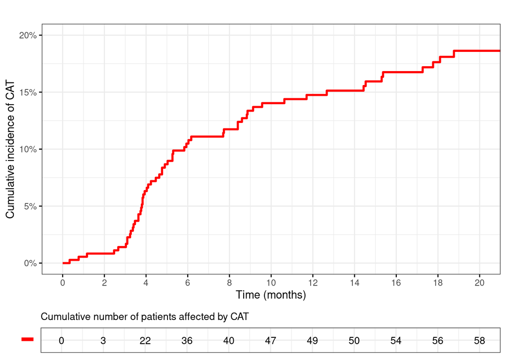

```r
# jpeg("../graphs/paper/KM_cuminc_cat_ggsurplot.jpeg", width = 6, height = 4, units = 'in', res = 700)

# Plot cumulative incidence curve
cat_cuminc_with_table = ggsurvplot(
  fit = cat_fit,
  data = cat_cuminc_data,
  fun = "event",
  censor = FALSE,
  conf.int = FALSE,
  xscale = 30,
  break.time.by = 60,
  surv.plot.height = 1.5,
  cumevents = TRUE,
  cumevents.y.text = FALSE,
  cumevents.height = 0.15,
  #tables.col = "strata",
  fontsize = 3.5,
  tables.y.text = FALSE, # color rectangle instead of text with strata name
  tables.theme = theme_cleantable(),
  legend = "none",
  xlab = "Time (months)",
  ylab = "Cumulative incidence of CAT",
  title = "",
  # Extend until month 20 so that all 59 VTE events can be seen in plot table
  xlim = c(0, 600), # 540
  ylim = c(0, 0.2),
  ggtheme = theme_bw(),
  palette = "red"
  )

# Add percentages in y axis
cat_cuminc_with_table$plot = cat_cuminc_with_table$plot +
  scale_y_continuous(labels = scales::percent, limits = c(0, 0.2))
# Customize risk table title
# Add new title to table
cat_cuminc_with_table$cumevents$labels$title = "Cumulative number of patients affected by CAT"
# Change table title font size
cat_cuminc_with_table$cumevents = cat_cuminc_with_table$cumevents +
  theme(plot.title = element_text(size = 10))

cat_cuminc_with_table
```

```r
# dev.off()
```